# Weights and Recoding

Neil Lund

2024-09-24

# Data set background: the ANES

- One of the longest running cross sectional surveys in American politics (pre/post election waves every 4 years)
  - Many of the questions are the same/similar over time so its an ideal resource for tracking public opinion change

## Surveys and weighting

- Most surveys do not set out to take a truly random sample of the population.
- Even if they do attempt to gather a random sample, differences in response rates may lead to a distorted picture of public opinion.
- Weights allow certain observations to count for more (or less) to bring the total sample more in line with the overall population.

## ANES weighting procedures

- ANES 2020 weighting procedures are described in their [User Guide and Codebook](https://electionstudies.org/data-center/2020-time-series-study/). There’s a lot of options, but usually you want either pre or post election weights
- Choose post election weights if you use any post-election variables, and pre-election weights otherwise.
  - The other weights are only useful when you are using specific subsets of the data.

(for this and any other survey: always consult the documentation for guidance on how/what to weight)

## ANES without weights

Non-Hispanic whites adults were only around 64% of the population on the 2020 census, so they’re clearly over represented here:

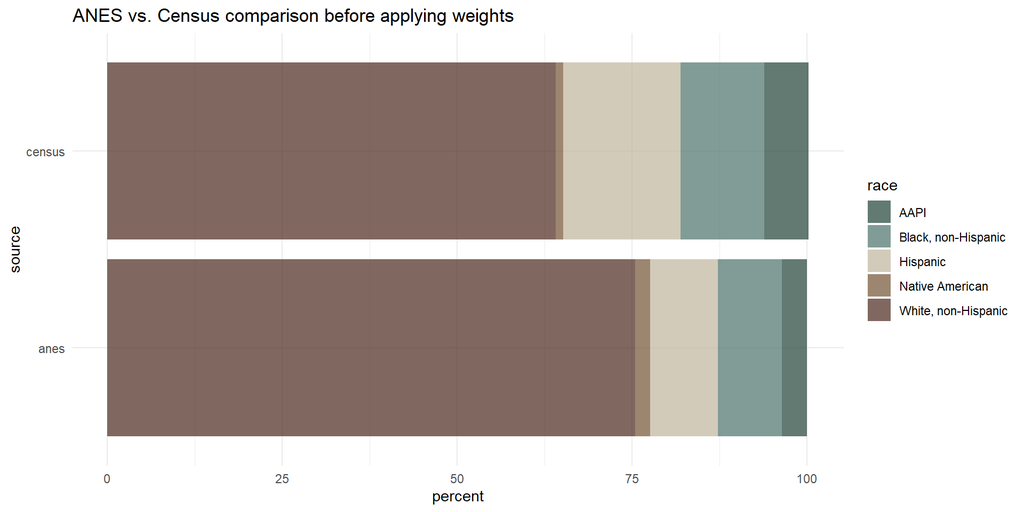

## ANES after weighting

But applying the appropriate weighting variable reduces their importance and brings them closer (albeit not perfectly matching) to the actual population estimate

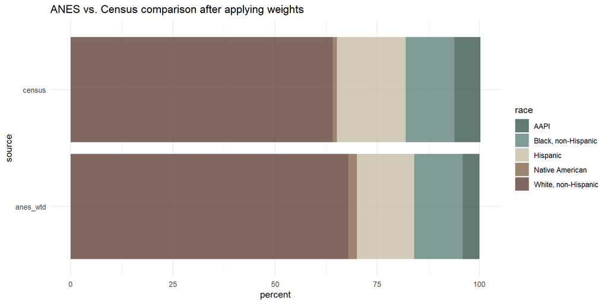

## Weighted frequencies

The creation of sample weights is a whole thing on its own. See [here for a good discussion](https://www.pewresearch.org/methods/2018/01/26/how-different-weighting-methods-work/).

However applying weights in most calculations is fairly simple: any time we would normally use a frequency we just use the value of the weighting variable instead:

```r
anes|>
  group_by(race)|>
  summarise( n = n(),
             `weighted n` = sum(weight)
             )|>
  ungroup()|>
  mutate(proportion = n/sum(n),
         `weighted proportion` = `weighted n` / sum(`weighted n`)

         )
```

| race | n | weighted n | proportion | weighted proportion |
| --- | --- | --- | --- | --- |
| AAPI | 284 | 325.60652 | 0.0342995 | 0.0393245 |
| Black, non-Hispanic | 726 | 938.71466 | 0.0876812 | 0.1133713 |
| Hispanic | 762 | 1106.57629 | 0.0920290 | 0.1336445 |
| Multiple Races | 271 | 284.91007 | 0.0327295 | 0.0344094 |
| Native American | 172 | 166.72893 | 0.0207729 | 0.0201363 |
| White, non-Hispanic | 5963 | 5374.01283 | 0.7201691 | 0.6490354 |
| NA | 102 | 83.45071 | 0.0123188 | 0.0100786 |

## Weighted frequencies

The `count` function from `dplyr` can also give us a slightly more compact version of this code:

```r
anes|>
  count(race, wt=weight, name='weighted n')|>
  mutate(`weighted proportion` = `weighted n`/sum(`weighted n`) )
```

| race | weighted n | weighted proportion |
| --- | --- | --- |
| AAPI | 325.60652 | 0.0393245 |
| Black, non-Hispanic | 938.71466 | 0.1133713 |
| Hispanic | 1106.57629 | 0.1336445 |
| Multiple Races | 284.91007 | 0.0344094 |
| Native American | 166.72893 | 0.0201363 |
| White, non-Hispanic | 5374.01283 | 0.6490354 |
| NA | 83.45071 | 0.0100786 |

## Weighting means

We can also calculate a weighted mean using a similar approach, but there’s a built-in function called `weighted.mean` that can be easier to use:

```r
anes|>
  summarise(`mean age` = mean(age, na.rm=T),
            `weighted mean age` = weighted.mean(age, w=weight, na.rm=T)
            )
```

| mean age | weighted mean age |
| --- | --- |
| 36.38203 | 32.99239 |

## Weighting Data: uncertainty

- Survey weights introduce additional sampling variance, so standard errors, confidence intervals and p-values will be misleading if we don’t account for this.
- We’ll mostly avoid this in this course, except to note that you can get appropriate measures of uncertainty using the `survey` package. Again: always consult the documentation when you’re working with survey data!

## Weighting Data: standard errors

- `id` is the primary sampling unit (`V200010c` in the original)
- `strata` is the variance stratum (`V200010d)`
- `weight` is just the full sample weighting variable: `V200010a`

I’ll specify the sampling design using `svydesign` and then get the mean and standard error using `svymean`.

Note: the point estimate is the same! The difference here only applies to measures of sampling variance.

```r
library(survey)

svyanes<-svydesign(id = ~id,  data=anes, strata=~stratum,  weight=~weight, nest=T)

# get the mean and SE of age
svymean(~age, svyanes, na.rm=T)
```

```
      mean     SE
age 32.992 0.3529
```

## Weighting Data: standard errors

There’s also a newer package called `srvyr` that allows you to use `dplyr`-like syntax to do survey analyses. This will give you the same answers but might feel a little less like you’re having to learn an entirely different set of commands to do data manipulation.

```r
library(srvyr)

svyanes<-anes|>
  as_survey_design(id =id,  data=anes, strata=stratum,  weight=weight, nest=T)

svyanes|>
  summarise(mean = survey_mean(age, na.rm=T))
```

| mean | mean_se |
| --- | --- |
| 32.99239 | 0.3528914 |

# Recoding

## Recoding with case_when

We’ll often need to make categorical variables have a different set of categories. We can use `case_when` to accomplish this.

## Party ID in 3 categories

The ANES includes a 7-category measure of Party ID but, in practice, “independent leaners” are often more similar to partisans than any other group.

```r
anes|>
  filter(!str_detect(vote16, "^\\-[0-9]"))|>
  filter(!str_detect(partyid, "^\\-[0-9]"))|>
  count(partyid, vote16, wt=weight)|>
  group_by(partyid)|>
  mutate(
         pct = scales::percent(n/sum(n),, accuracy = 1)

         )|>
  select(-n)|>
  pivot_wider(names_from=vote16, values_from=pct)|>
  knitr::kable()|>
  kable_styling(full_width = F)
```

| partyid | 1. Hillary Clinton | 2. Donald Trump | 5. Other {SPECIFY} |
| --- | --- | --- | --- |
| 1. Strong Democrat | 96% | 2% | 1% |
| 2. Not very strong Democrat | 84% | 11% | 5% |
| 3. Independent-Democrat | 83% | 7% | 10% |
| 4. Independent | 43% | 37% | 20% |
| 5. Independent-Republican | 11% | 77% | 12% |
| 6. Not very strong Republican | 14% | 77% | 10% |
| 7. Strong Republican | 2% | 96% | 2% |

## Recoding Party ID

In general terms, we want to make

| 7 Category | 3 category |
| --- | --- |
| Strong Republican | Republican |
| Not Very Strong Republican | Republican |
| Independent Republican | Republican |
| Independent | Independent |
| Independent Democrat | Democrat |
| Not Very Strong Democrat | Democrat |
| Strong Democrat | Democrat |

## As an if-else

We can think of the problem as a series of if-else statements, but in practice this ends up being extremely messy in R

```
If party ID is Strong Republican then PID 3 is Republican,

else if Party ID is Not Very Strong Republican then Republican,

else if ...
```

```r
pid3<-with(anes, {
  ifelse(
    partyid %in% c(
      "1. Strong Democrat",
      "2. Not very strong Democrat",
      "3. Independent-Democrat"
    ),
    "Democrat",
    ifelse(
      partyid == "Independent",
      "Independent",
      ifelse(
        partyid %in% c(
          "5. Independent-Republican",
          "6. Not very strong Republican",
          "7. Strong Republican"
        ),
        "Republican",
        NA
      )
    )
  )
})
```

## case_when

The `case_when` function will implement this logic in a slightly less unwieldy format. The basic syntax will look something like this:

```
case_when(condition1 ~ label1,
          condition2 ~ label2,
          condition3 ~ label3...
)
```

Each condition statement will be a logical expression that can yield `TRUE` or `FALSE`, and arguments will be read in order so that condition2 is only checked if condition 1 fails. If all conditions fail, then the resulting variable will be treated as an `NA` (but this can be overridden with the `.default` argument)

```r
anes <- anes |>
  mutate(
    pid3cat = case_when(
        partyid == "1. Strong Democrat" ~ "Democrat",
        partyid == "2. Not very strong Democrat" ~ "Democrat",
        partyid == "3. Independent-Democrat" ~ "Democrat",
        partyid == "4. Independent" ~ "Independent",
        partyid == "5. Independent-Republican" ~ "Republican",
        partyid == "6. Not very strong Republican" ~ "Republican",
        partyid == "7. Strong Republican" ~ "Republican"
    ))
```

## case_when: slightly more compact

Sometimes we can make these expressions even shorter with careful use of `str_detect` or by converting factor variables to numbers and then converting based on a numeric comparison.

- string based
- number based

```r
anes<-anes|>
  mutate(pid3_v1 = case_when(str_detect(partyid, "Democrat") ~ "Democrat",
                             str_detect(partyid, "Republican") ~ "Republican",
                             partyid == "4. Independent" ~ "Independent"
                             ))
```

```r
anes<-anes|>
  mutate(pid3_v2 = case_when(as.numeric(partyid)%in%3:5 ~ "Democrat",
                             as.numeric(partyid) == 6 ~ "Independent",
                             as.numeric(partyid) > 6 ~ "Republican"
                             ))
```

## Checking your work

When you recode, you should assign the results to a new variable and then compare the new variable to the old values to make sure things look right.

One easy way to do that is by using `select` and `distinct` to view just the unique values of each of your variables side by side:

```r
anes|>
  select(partyid, pid3cat)|>
  distinct()|>
  arrange(partyid)
```

| partyid | pid3cat |
| --- | --- |
| -9. Refused | NA |
| -8. Don’t know | NA |
| 1. Strong Democrat | Democrat |
| 2. Not very strong Democrat | Democrat |
| 3. Independent-Democrat | Democrat |
| 4. Independent | Independent |
| 5. Independent-Republican | Republican |
| 6. Not very strong Republican | Republican |
| 7. Strong Republican | Republican |

## Reordering factor levels

Many plotting and table functions will default to putting categorical variables in alphabetical order. This actually works out fine for this example, but this may not make sense for a lot of variables

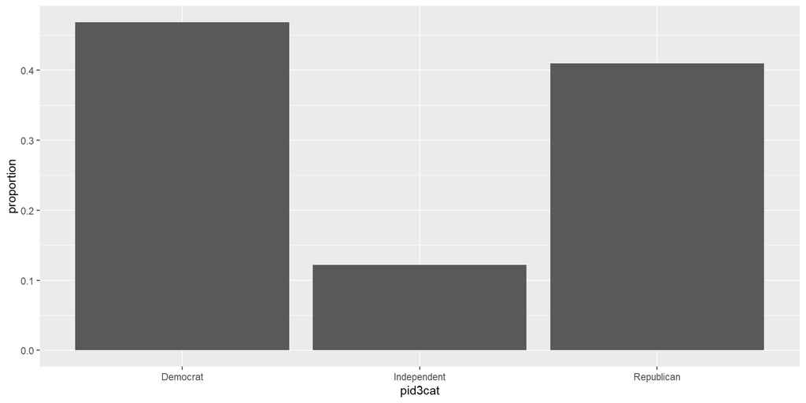

## forcats

To override this behavior, you can use functions from the `forcats` package ([link](https://forcats.tidyverse.org/))

`fct_relevel` will take a factor variable and then reorder the labels in whatever order you specify.

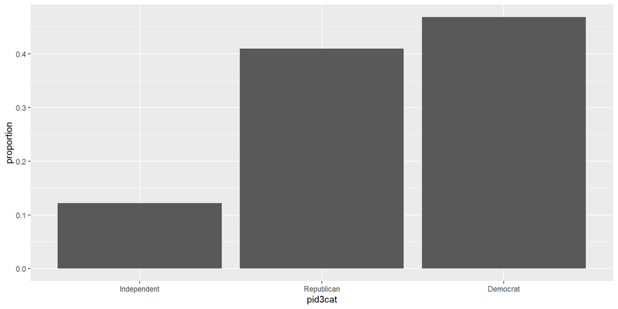

```r
anes|>
  count(pid3cat, wt=weight)|>
  drop_na()|>  # remove NA values
  mutate(pid3cat = fct_relevel(pid3cat, "Independent", "Republican", "Democrat"))|>
  mutate(proportion = n/sum(n))|>
  ggplot(aes(x=pid3cat, y=proportion)) +
  geom_bar(stat='identity')
```

# Excercise

[Download RMD file here](https://github.com/Neilblund/GVPT628-Fall2024/blob/main/Week%205/weights_and_recoding.Rmd)